# Análisis de Conglomerados, Encuesta Nacional de Opinión sobre TIC

### 4.2.2 Estado civil (P150)

Respecto al estado civil, podemos identificar que los tres grupos se conforman de una manera similar, siendo que el estado civil más representativo es ser soltero, seguido de casado o conviviente. El tema de soltero tiene coherencia con la estructura de edades y la ocupación principal de la mayoría de los encuestados, estudiantes, mientras que las segunda categoría, la de casado o coviviente, agrupa casi a todo el resto de encuestados.

```
##
##        A    B    C
##   1 0.26 0.17 0.06
##   2 0.24 0.13 0.05
##   3 0.04 0.01 0.00
##   4 0.02 0.00 0.00
```

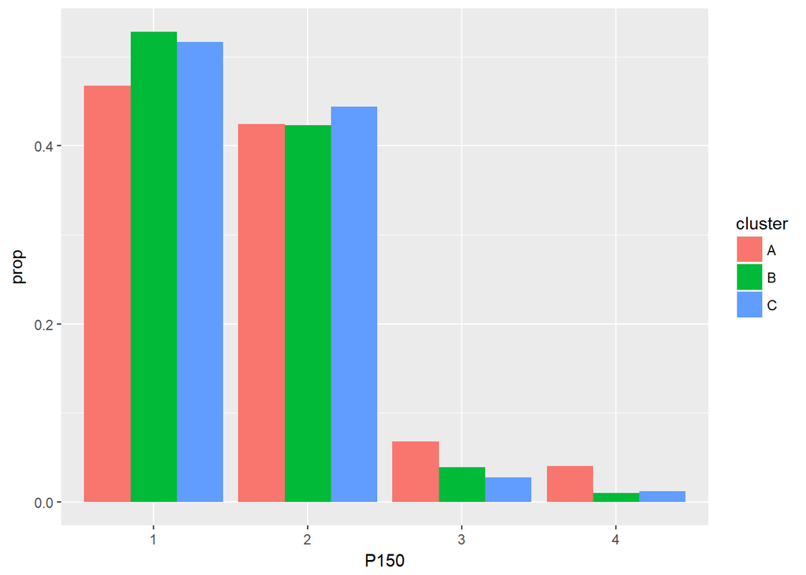

### 4.2.3 Tenencia de internet fijo en casa o módem (P23)

El acceso a internet en casa, tiene coherencia con la posesión de equipos de computación y además es una de las características donde encontramos más diferencias. EL 90% de las personas del grupo A no tienen acceso a internet en sus hogares juntamente con el 52% del grupo B y el 49% del grupo C. Este aspecto es interesante y puede ser uno de los factores que ayuden a explicar porque las personas de los grupos B y C estan más conectados que las del grupo A. Además, si bien las diferencias entre las disponibilidades de internet en sus hogares de los grupos B y C no son grandes, observamos que algo que si diferencia a estos grupos es el uso que le dan a esta conexión, siendo que el grupo C está más conectado.

```
##
##        A    B    C
##   1 0.01 0.06 0.03
##   2 0.04 0.09 0.03
##   3 0.51 0.16 0.06
```

```
##
##        A    B    C
##   1 0.02 0.21 0.23
##   2 0.08 0.28 0.28
##   3 0.90 0.52 0.49
```

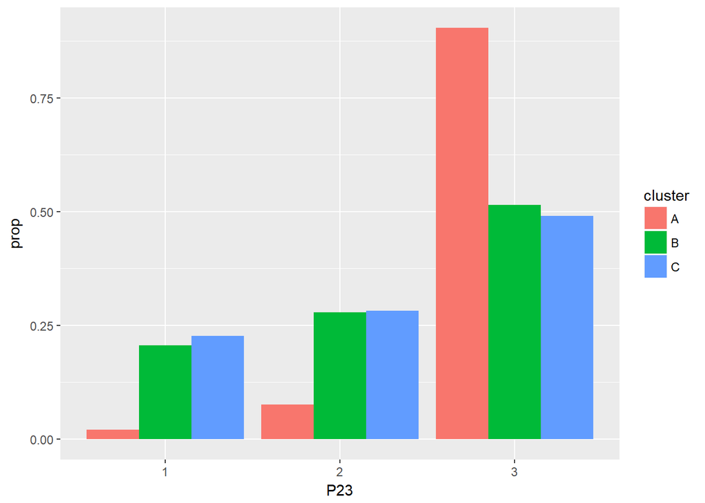

### 4.2.4 Sistema Operativo en celular (P36A)

El sistema operativo que utilizan los teléfonos móviles de los entrevistados nos muestra un claro dominio de Android, siendo la categoría más importante para los 3 grupos y llegando a abarcar el 88% del total de la encuesta. Por otra parte, se observa que el conglomerado A tiene menos participación en el uso de Android que los otros grupos, y al mismo tiempo llega a tener el 10% de sus integrantes en la categoría de otros. Esto nos muestra que en el grupo A hay más personas que utilizan celulares convencionales, es decir aquellos que no son smarthphones, que utilizan otros sistemas operativos diferentes a Android y iOS. Esto también es coherente con el hecho de que en promedio este grupo gasta menos en sus teléfonos. Finalmente, si bien la cuota de mercado de iOS es baja respecto a los demás sistemas operativos, podemos observar que para el grupo C esta categoría es importante, abarcando el 7% del conglomerado.

```
##
##        A    B    C
##   1 0.48 0.29 0.11
##   2 0.02 0.01 0.01
##   3 0.01 0.01 0.00
##   4 0.06 0.00 0.00
```

```
##
##        A    B    C
##   1 0.84 0.92 0.91
##   2 0.03 0.04 0.07
##   3 0.02 0.02 0.01
##   4 0.10 0.01 0.01
```

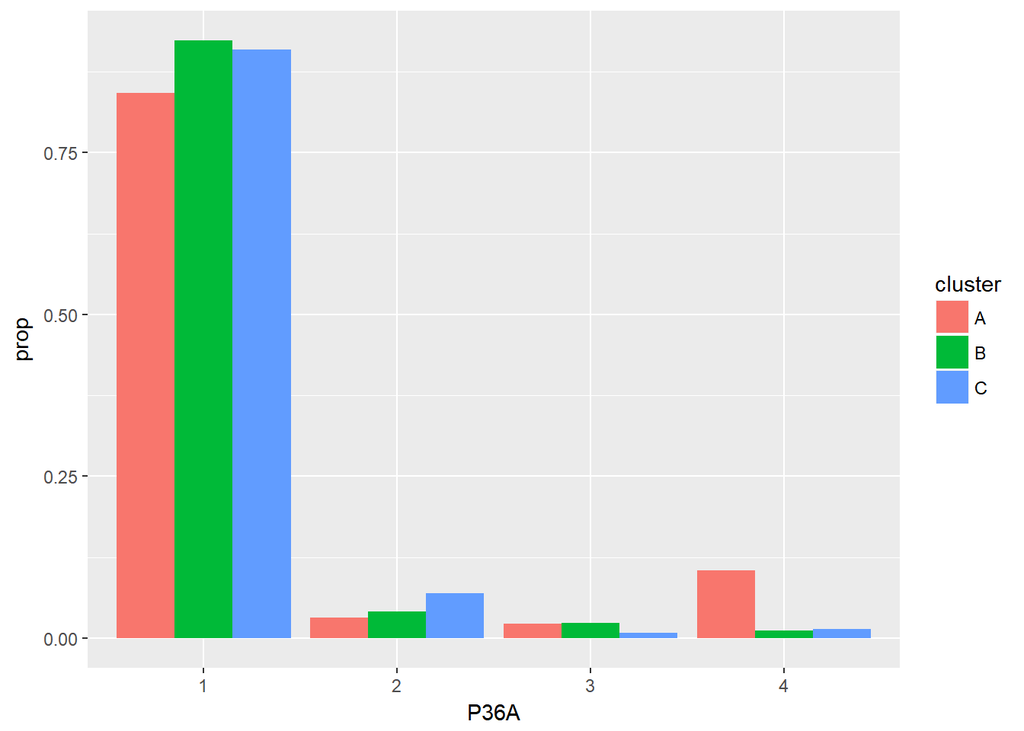

### 4.2.5 Consideración de medio más rápido (P134)

Las preferencias de los grupos respecto a qué medio de comunicación consideran más rápido son parecidas en rasgos generales. En los tres grupos existe una mayoría que considera que la televisión (categoría 1) es el medio más rápido, donde el grupo A resalta en esta opinión. Una segunda proporción importante en los tres grupos considera que las redes sociales (categoría 6) son el medio más rápido, y en esta opinión resalta el grupo B. Por otra parte, una tercera proporción importante de A considera que la radio es el medio más rápido mientras que las respectivas proporciones en los grupos B y C consideran más rápidas a las páginas web (categoría 5). Finalmente, se puede notar que si bien las cuartas proporciones más importantes de los grupos B y C consideran a la radio como medio más rapido, el grupo C resalta en esta opinión respecto a B.

```
##
##        A    B    C
##   1 0.29 0.14 0.06
##   2 0.09 0.02 0.01
##   3 0.01 0.01 0.00
##   4 0.01 0.01 0.00
##   5 0.05 0.05 0.02
##   6 0.11 0.09 0.02
##   7 0.00 0.00 0.00
```

```
##
##        A    B    C
##   1 0.52 0.46 0.46
##   2 0.15 0.06 0.10
##   3 0.02 0.02 0.03
##   4 0.02 0.04 0.04
##   5 0.09 0.15 0.15
##   6 0.20 0.27 0.19
##   7 0.01 0.00 0.02
```

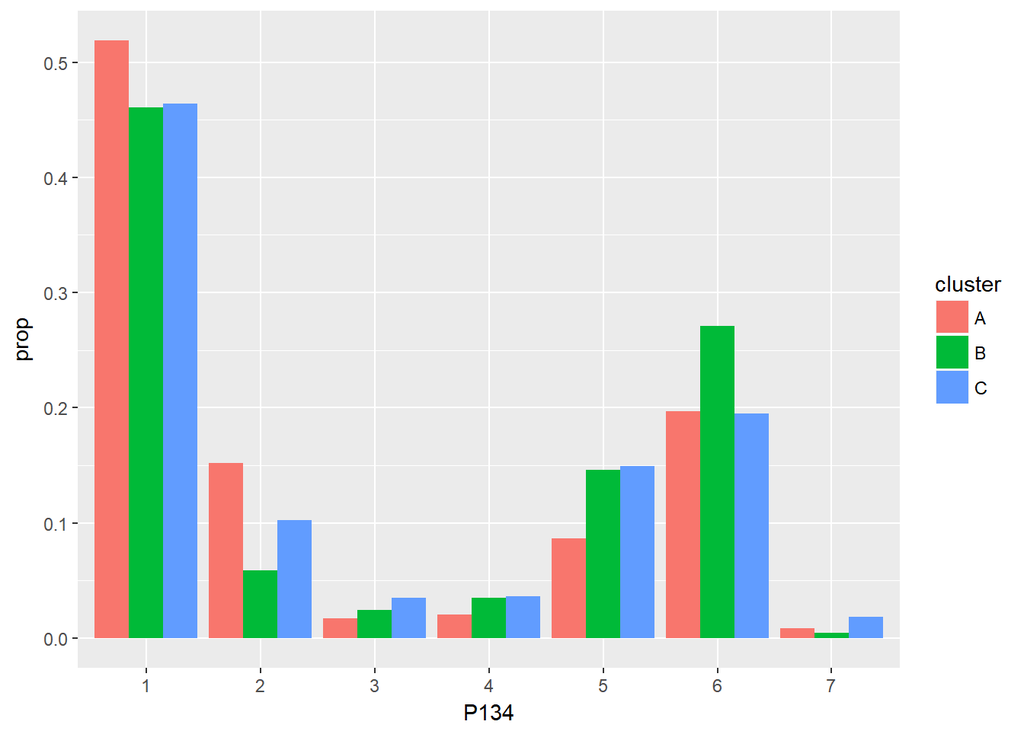

### 4.2.6 Consideración de medio más serio (P136)

Si bien las redes sociales son consideradas, después de la TV, como un medio rápido, estas en general no se consideran un medio serio entre los encuestados. Las perspectivas de las mayorías en los grupos nos muestran que la TV sigue siendo el medio de comunicación más serio. Por otra parte, se resalta que los periódicos son una fuente seria de información para proporciones de segunda importancia en los grupos B y C. En cuanto a la radio, el 20% del grupo A la considera una fuente de información seria, mientras que esta proporción en los demás grupos ronda el 12%. Al mismo tiempo es interesante resaltar que el grupo C, se muestra en general más escéptico que los otros grupos respecto a la seriedad de los medios de comunicación, siendo que el 8% de las personas del grupo C consideran que ningún medio de comunicación es serio.

```
##
##        A    B    C
##   1 0.29 0.14 0.06
##   2 0.11 0.04 0.01
##   3 0.09 0.08 0.03
##   4 0.01 0.01 0.00
##   5 0.02 0.02 0.01
##   6 0.01 0.01 0.00
##   7 0.02 0.01 0.01
```

```
##
##        A    B    C
##   1 0.51 0.43 0.49
##   2 0.20 0.13 0.10
##   3 0.17 0.26 0.21
##   4 0.02 0.04 0.04
##   5 0.04 0.06 0.05
##   6 0.03 0.04 0.03
##   7 0.04 0.05 0.08
```

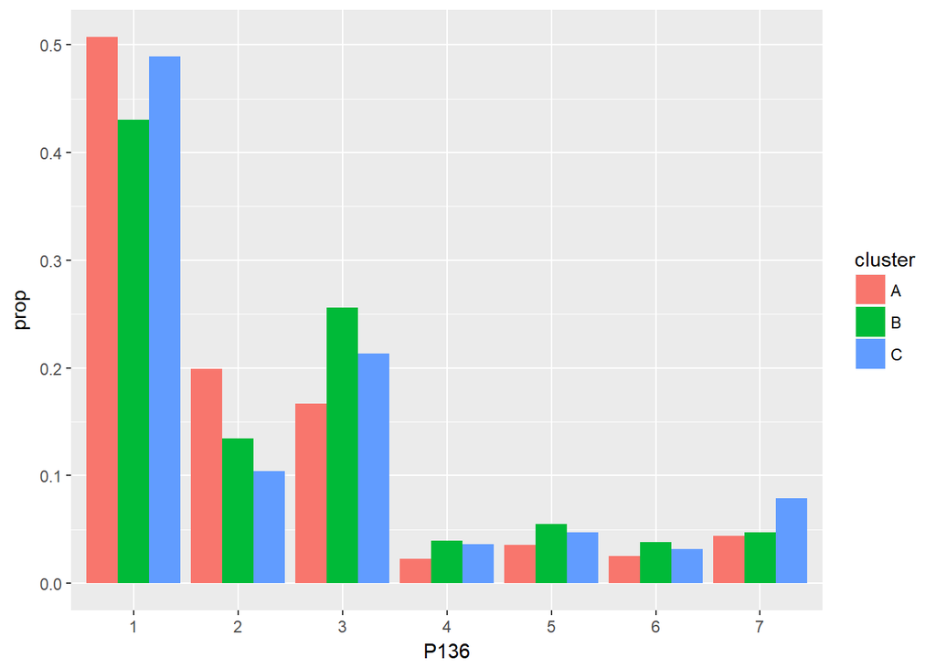

### 4.2.7 Medio preferido para informarse sobre noticias nacionales (P129A)

La televisión es uno de los medios mejor posicionados en varios aspectos, y en este caso, es el medio preferido para obtener noticias nacionales para los 3 grupos. También podemos observar que las personas del grupo A, después de la televisión prefieren la radio y como tercera fuente a las redes sociales, mientras que el grupo B tiene un comportamiento diferente, prefiere informarse por las redes sociales en vez de por la radio. El grupo C mantiene una relación muy parecida respecto a tener como fuentes de información nacional a las redes sociales y la radio.

```
##
##        A    B    C
##   1 0.42 0.22 0.08
##   2 0.06 0.01 0.01
##   3 0.01 0.02 0.01
##   4 0.01 0.01 0.00
##   5 0.01 0.02 0.01
##   6 0.04 0.03 0.01
##   7 0.00 0.00 0.00
##   8 0.00 0.00 0.00
```

```
##
##        A    B    C
##   1 0.75 0.70 0.67
##   2 0.11 0.05 0.09
##   3 0.02 0.05 0.05
##   4 0.01 0.03 0.03
##   5 0.03 0.07 0.05
##   6 0.07 0.09 0.09
##   7 0.01 0.01 0.02
##   8 0.00 0.00 0.00
```

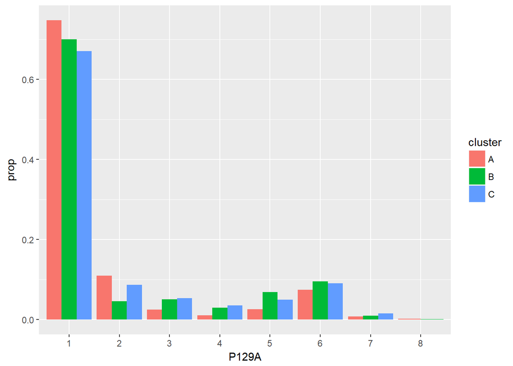

### 4.2.8 Medio preferido para informarse sobre ciencia y tecnología (P131A)

Después de la televisión, el medio preferido para informarse de ciencia y tecnología son las páginas web, seguido de las redes sociales. Esta preferencia por las páginas web puede deberse al hecho de que en el contexto nacional el contenido de ciencia y tecnología es muy escazo en los diferentes medios de comunicación, mientras que en las páginas web se pude acceder a este tipo de contenido de manera más fácil ya que a nivel internacional hay sitios especializados en estos aspectos. En cuanto a las redes sociales, se puede notar que estas suelen atraer la atención de los interesados a través de distintas comunidades sobre temas de ciencia y tecnología para luego funcionar como un puente hacia páginas web.

```
##
##        A    B    C
##   1 0.30 0.12 0.05
##   2 0.05 0.02 0.01
##   3 0.02 0.02 0.01
##   4 0.02 0.02 0.01
##   5 0.08 0.08 0.03
##   6 0.08 0.05 0.01
##   7 0.01 0.00 0.00
##   8 0.01 0.00 0.00
```

```
##
##        A    B    C
##   1 0.53 0.39 0.39
##   2 0.09 0.05 0.06
##   3 0.04 0.06 0.09
##   4 0.03 0.07 0.06
##   5 0.14 0.26 0.27
##   6 0.14 0.16 0.12
##   7 0.02 0.01 0.01
##   8 0.01 0.01 0.00
```

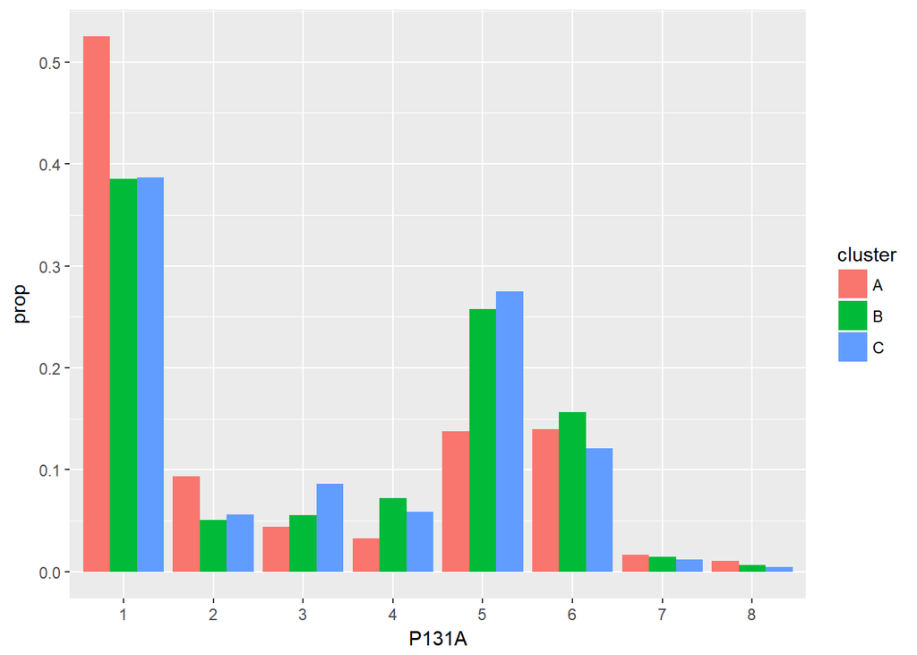

### 4.2.9 Medio preferido para informarse sobre Negocios/oportunidades laborales/bienes o servicios (P133A)

En este aspecto, cabe resaltar la imporancia que toman los periódicos impresos, siendo que llega a ser el segundo medio de comunicación preferido para informarse sobre negocios, oportunidades laborales, bienes o servicios. Otra vez un medio importante para el grupo A es la radio (18%), mientras que los grupos B y C prefieren ver páginas web y redes sociales.

```
##
##        A    B    C
##   1 0.25 0.11 0.04
##   2 0.10 0.04 0.01
##   3 0.10 0.06 0.02
##   4 0.01 0.01 0.00
##   5 0.03 0.04 0.02
##   6 0.05 0.04 0.01
##   7 0.02 0.01 0.01
##   8 0.01 0.01 0.00
```

```
##
##        A    B    C
##   1 0.44 0.34 0.32
##   2 0.18 0.11 0.10
##   3 0.18 0.20 0.19
##   4 0.02 0.03 0.03
##   5 0.05 0.13 0.17
##   6 0.09 0.13 0.12
##   7 0.03 0.04 0.06
##   8 0.01 0.02 0.01
```

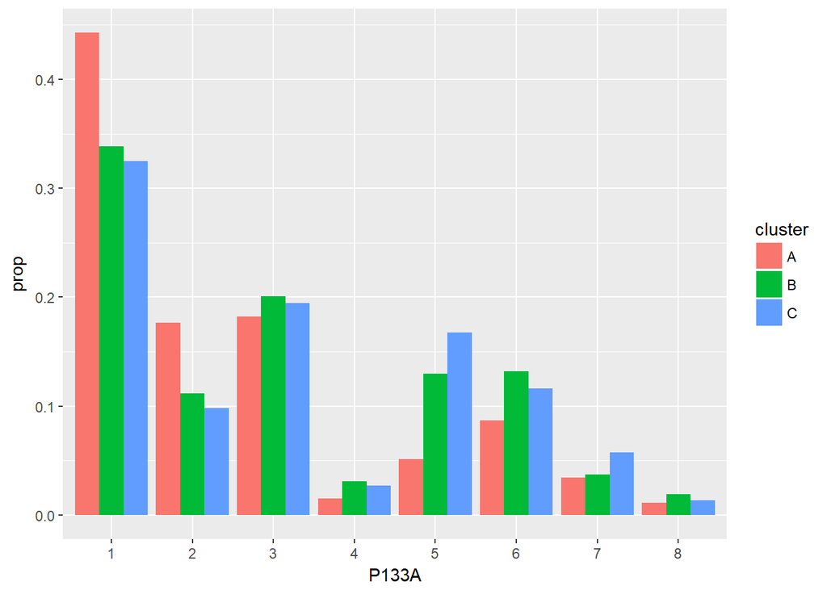

### 4.2.10 Tipo de programa preferido en televisión (P15A)

Podemos observar que uno de los tipos de programas más preferidos para ver en la televisión es un programa de noticias, para los 3 grupos. Un siguiente tipo de contenido que les interesa a las personas es el de entretenimiento, y como tercero programación de deportes. El comportamiento general se aplica a los 3 grupos, pero es interesante observar que tan solo el 1% del grupo B no ve televisión, frente a un 5% del grupo A y un 6% del grupo C, siendo este último grupo uno que más bienes duraderos posee, es decir que no ven televisión por elección propia y no por restricciones de no tener televisor.

```
##
##        A    B    C
##   1 0.40 0.23 0.08
##   2 0.05 0.03 0.01
##   3 0.01 0.01 0.00
##   4 0.08 0.05 0.02
##   5 0.00 0.00 0.00
##   6 0.03 0.00 0.01
```

```
##
##        A    B    C
##   1 0.70 0.72 0.67
##   2 0.08 0.10 0.11
##   3 0.01 0.03 0.02
##   4 0.15 0.15 0.13
##   5 0.00 0.00 0.01
##   6 0.05 0.01 0.06
```

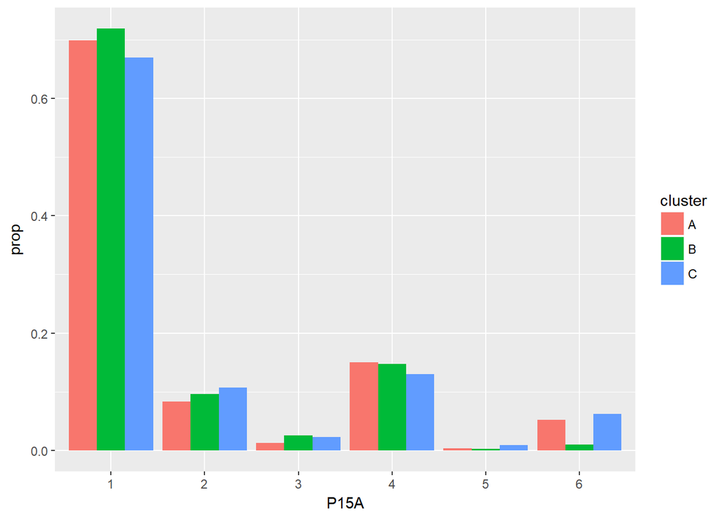

## 4.3 Interpretación de los conglomerados

Haciendo una división de algunas de las variables que consideramos en nuestro análisis podemos observar lo siguiente:

- **División de bienes duraderos**  
  Los bienes duraderos son aquellos que no se renuevan constantemente, por ejemplo un computador, este, se espera que tenga alredor de unos 4 años de vida útil en un contexto doméstico, mientras que los bienes no duraderos son aquellos que por sus características, se renuevan con mayor frecuencia, por ejemplo los alimentos. Hacemos énfasis en esta división porque notamos que las características de nuestros conglomerados aparentemente tienen una relación con estás variables. En los trabajos de Cortinovis 1993 y Filmer & Pritchett 2001 se utilizan algunos bienes duraderos para hacer una clasificación de estatus socio económico de las familias. En este aspecto el grupo A se diferencia por no poseer varios de los bienes duraderos considerados, mientras que los grupos B y C tienen indicadores muy parecidos y estos si poseen (en una proporción significativamente mayor que A), bienes duraderos.
- **División de servicios TICs** Al mismo tiempo los servicios de TICs como ser TV cable en el hogar o internet domiciliario también marcan diferencias significativas entre las características del grupo A respecto a los grupos B y C.
- **Características hogar** En las características del hogar, como ser el nivel de instrucción del jefe del hogar, o los ingresos promedios reportados, tenemos diferencias importantes entre el grupo A frente a los grupos B y C. Otra vez hay una marcada división.
- **Intensidad en uso de la TICs** Respecto al uso de las TICs tenemos diferencias entre los grupos, tanto A como B y C presentan comportamientos diferentes en esta “intensidad” en el uso de las TIC. Unos tienen restricciones para poder utilizarlas, otros prefieren utilizar redes sociales, y los demás prefieren diversificar sus fuentes de información.

Dado que la clasificación que hicimos a traves de K-Prototypes es no supervisada, los grupos encontrados no tenían a priori una interpretación. Pero una vez analizadas las variables podemos identificar que parece haber 2 niveles de clasificación, el primero divide al grupo A de los grupos B y C, esta primera división podemos interpretarla como una clasificación de personas por “estatus socio-económico”. En esta división , siguiendo la línea del trabajo de Cortinovis 1993, se tiene en el grupo A a personas de escasos recursos respecto a los de la categoría B y C. Esto se ve reflejado en variables como la posesión de bienes durables, niveles de educación del jefe del hogar, gasto en el último televisor, etc.

La segunda división, aquella que separa a los grupos B y C, parece ser la interacción y uso que hacen de las TICs. Es decir, si bien el grupo B y C tienen proporciones de acceso a las TICs parecidas (a favor del grupo C), es justamente el conglomerado C el que utiliza estos medios con una mayor intensidad (frecuencia de uso), y con preferencias más diversas respecto a los fines para cada una de estás tecnologías. Mientras que el grupo B está más enfocado en las redes sociales.

En los siguientes puntos detallaremos estás diferencias, características y perfiles encontrados entre los grupos.

### 4.3.1 Conglomerado A: Mayoría

El conglomerado A agrupa al 56.59% de la población, este grupo esta caracterizado por tener limitantes al momento de interactuar con las TIC. Uno de los motivos de estas diferencias es que en su mayoría no poseen en su hogar ni una computadora de escritorio, portatil o tablet, con la que podrían acercarse más a estas técnologías. Al mismo tiempo, el 90% de las personas del grupo no tienen acceso a internet fijo ni modem en su hogar. Probablemente uno de los principales motivos de estas restricciones sea el ingreso y riqueza del hogar; la mayoría de las personas de este grupo no tiene bienes durables (qué suelen ser proxys de riqueza) como, microondas (94% no tiene), lavadora de ropa (90% no tiene), etc. En promedio son los que menos gastaron en la compra de su últimos celulares, al igual que al adquirir su último televisor. Además el nivel de instrucción de la mayoria de jefes(as) de hogar es menor que de los otros grupos, siendo que el 73% de los jefes de hogar del grupo tienen la secundaria completa o algún grado menor de instrucción. Respecto a los ingresos mensuales promedio del hogar declarados acumulan el 79% de familias que mensualmente tienen Bs 3.500 o menos.

Estas personas tienen preferencias por medio de comunicación más tradicionales como ser la TV y la radio. No interactuan mucho con la tecnología (el 68% no usa equipos de computación ni tablets); y aquellos del grupo que si lo hacen, tienen una frecuencia baja, el 42% de las personas que si utilizan estos equipos lo hacen de 1 a 3 veces por semana, nuevamente por la limitante que no tienen estos equipos en casa y para acceder a ellos deben hacer esfuerzos como acudir a cafes internet. También es importante resaltar que es el grupo que cuenta relativamente con más cuenta propistas respecto al total del grupo. Respecto a su distribución geográfica, si bien este grupo esta principalmente concentrado en centros poblados de 2.000 a 10.000 habiantes (40% del conglomerado), su participación no es trivial en las ciudades capitales (32% de conglomerado) ni en ciudades intermedias (28% del congloemrado).

Uno de los comportamientos más interesantes es que si bien las personas de este grupo gastaron en promedio menos en la compra de su último celular, que los otros grupos, este conglomerado en particular presenta una mayor variabilidad en esta variable. Una de las hipótesis que podría explicar esto, es que justamente las personas de este grupo que quieren interactuar con los TICs, lo hacen preferentemente a través de sus teléfonos celulares, y para tener una mejor experiencia es que invierten más en este bien ya que en su mayoria no tienen acceso a computadores ni internet fijo en su hogar.

### 4.3.2 Conglomerado B: Intermedio

Este grupo aglutina al 31.45% de la población, dentro de este conglomerado, el 86% de las personas tienen al menos un computador de escritorio, portatil o tablet en su hogar. Respecto al nivel de instrucción del jefe del hogar tenemos que la categoría más importante es la de universidad terminada, pero algo que diferencia a este grupo es el hecho que tiene un 17% de jefes de hogar con nivel de instrucción técnico. Consideran a las redes sociales como uno de sus principales medios de comunicación después de la televisión, y las consideran el medio más participativo. El 27% de las personas del grupo B consideran a las redes sociales como el medio de comunicación más rapido después de la TV. Además, para informarse de noticias nacionales, después de la televisión como principal fuente, el 9% prefiere las redes sociales y un 7% las páginas web.

En este grupo el 58% de las personas utiliza los equipos de computación o tablets entre 3 a 7 días a la semana, con un 22% de personas que los usan todos los días.

Es curioso encontrar que justamente el grupo que más énfasis hace en las redes sociales como un medio de comunicación importante, pase menos tiempo usando equipos de computación respecto al grupo C, a pesar de que tienen oportunidades de acceso parecidas. Parece ser que las personas del grupo B están más “entusiasmadas” con la conexión a las redes sociales, y a pesar de que se conectan menos, le dan más importancia a este medio en general.

### 4.3.3 Conglomerado C: Minoria

El conglomerado C tiene al 11.96% de la población, al igual que el grupo B, este grupo tiene acceso a los bienes durables, el 81% de las personas del grupo tienen un computador de escritorio, portatil o tablet en su hogar. En el grado de instrucción del jefe del hogar, si bien la mayor frecuencia es la de universidad completa, el comportamiento interesante es que en este grupo están más personas con posgrados, el 10% de los jefes de hogar de las familias del grupo tiene un posgrado, frente a un 6% del grupo B. Otra característica de este conglomerado es el hecho de que son los más escépticos respecto a la imparcialidad de los medios de comunicación, siendo que el 20% de las personas del grupo consideran que ningún medio de comunicación es imparcial. Al mismo tiempo, el 8% de las personas del grupo consideran que ningún medio de comunicación es serio. Para informase de noticias nacionales prefieren a la televisión al igual que los otros grupos, pero se diferencian del grupo B por que además prefieren a la par otras fuentes para informarse de noticias nacionales, redes sociales (9%) y radio (9%), lo que nos muestra una diversificación en las fuentes que consultan las personas de este grupo. En otros aspectos, para este grupo los periódicos impresos y la radio son también medios de comunicación alternativos a la television y las redes sociales.

En la distribución geográfica del grupo se observaron concentraciones en La Paz (22%) y Cochabamba(15%), un aspecto interesante ya que los demás grupos no mostraban una predominancia de locación geográfica por departamentos. Justamente Cochabamba es uno de los centros tecnológicos más importantes de Bolivia y La Paz, al ser sede de gobierno, reuné grán parte del capital humano del país.

Finalmente, una de las diferencias más importantes respecto al grupo B es la intensidad del uso de las TICs. El 62% de las personas de este grupo utilizan equipos de computación o tablets entre 3 a 7 días a la semana, siendo que el 31% de las personas los usan todos los días.

# 5. Conclusiones

Fue posible identificar conglomerados en la base de datos siguiendo en primera instancia una etapa de pre-procesamiento seguida por una etapa de modelación donde se consideraron variables categóricas y numéricas. En la etapa de modelación se lograron identificar tres conglomerados considerando un problema de aprendizaje no supervisado, y posteriormente, planteando un problema de aprendizaje supervisado, se logró encontrar un subconjunto de variables imporantes en la definición de los mismos. Para resolver el problema de aprendizaje no supervisado se consideró el modelo K-Prototypes y para el problema de aprendizaje supervisado el modelo Random Forest.

En cuanto a los resultados, a pesar de que nuestra clasificación por conglomerados no tenía un criterio separador a priori, pudimos identificar 3 tipos de categorías claramente diferenciadas y detalladas en la sección anterior.

La clasificación obtenida fue a 2 niveles, el primero, diferenciando a aquellas personas que tienen restricciones estructurales para poder acceder a la información y la tecnología. Probablemente estas restricciones se deban a un tema de escasos recursos, pero dentro de este grupo, dadas estas restricciones, se identifican personas que hacen un esfuerzo en acceder a medios que les permitan conectarse a las TIC, y en este contexto invierten en “smartphones”.

El segundo nivel de clasificación se da entre aquellas personas que tienen la posibilidad de tener acceso a tecnologías como computadoras y tablets dentro de sus hogares, además de complementarlas con conexiones a internet. Dentro de este conjunto se diferencian dos grupos, uno de ellos que tiene una preferencia marcada por las redes sociales como medios de comunicación, frente a otro grupo que es más cauteloso y escéptico respecto a la confiabilidad de las fuentes y prefiere diversificarlas para obtener mayor información.

# 6. Recomendaciones

## 6.1. Recomendaciones metodológicas.

Es recomendable que en la base de datos se aplique un proceso de ingeniería de variables para incorporar variables que aporten información o incluso puedan marcar mayores diferencias entre los conglomerados.

Para la selección de variables importantes se recomienda obtener medidas de importancia condicionales. En el presente estudio no se logró hacer este análisis por una falta de capacidad computacional en los equipos usados.

En cuanto al análisis de valores faltantes, es recomendable hacer un tratamiento más minucioso al respecto. Haciendo referencia a la primera recomendación, podrían generarse varaibles indicatrices que aporten información respecto al grado de confianza o voluntad de los encuestados a la hora de responder preguntas.

En cuanto a los resultados, se recomienda hacer un contraste entre distribuciones de variables que también se consideran en las encuestas de hogares realizadas por el INE, ya que en general, se espería encontrar similitudes. Un hallazgo que permite plantear esta recomendacion es la alta concentración de estudiantes entre los encuestados.

## 6.2. Recomendaciones de política.

El conglomerado que presenta restricciones en el acceso a medios para interactuar con la tecnología e información de las TIC, representa una mayoría dentro del contexto nacional (56.59%). La labor pendiente en este tema es llevar a cabo políticas públicas para poder democratizar el acceso a estos medios. Dar la posibilidad a las personas de este grupo a que puedan acceder a oportunidades para desarrollar habilidades tecnológicas.

La política de democratización de las TICs, debe ser desarrollada con un enfoque crítico, para que las personas que se interiorizen en el tema, puedan consultar varias fuentes al momento de tomar decisiones, y al mismo tiempo no se sientan abrumadas con la cantidad de inforación disponible en la red.

## 6.3 Líneas de investigación.

Dentro de la exploración de esta base de datos y con el análisis de los conglomerados, se plantearon hipótesis interesantes como: el nivel de instrucción influye en el escepticismo sobre la imparcialidad y seriedad de los medios de comunicación; las personas de escasos recursos interesadas en temas de tecnología hacen un esfuerzo mayor para poder acceder a medios con los que puedan conectarse y navegar por internet, principalemente celulares; la televisión es el medio de comunicación más importante para las personas, pero medios alternativos como las redes sociales van cobrando fuerza. Por otra parte, se plantean interronates interesantes como: ¿Serán representativos los resultados en la población?; ¿Cuál sería el comportamiento de un cuarto conglomerado?; y ¿Cuáles serían los resultados si se consideran otros métodos de selección de variables importantes?. Estás hipótesis e interrogantes pueden ser desarrolladas en profundidad en posteriores trabajos y aportar a la línea de investigación sobre TIC en Bolivia.

# 7. Referencias

- Van Buuren, Stef & Groothuis-Oudshoorn, Catharina. (2011). MICE: Multivariate Imputation by Chained Equations in R. Journal of Statistical Software. 45. 10.18637/jss.v045.i03.
- Zhexue Huang. (1998). “Extensions to the k-Means Algorithm for Clustering Large Data Sets with Categorical Values”. Data Mining and Knowledge Discovery 2: 283 – 304.
- Ismaili O.A., Lemaire V., Cornuéjols A. (2014). “A supervised methodology to measure the variables contribution to a clustering”. International Conference on Neural Information Processing: 159-166.
- Strobl, Carolin & Hothorn, Torsten & Zeileis, Achim. (2009). Party on! A New, Conditional Variable Importance Measure for Random Forests Available in the party Package. The R Journal. 1. 14-17.
- Cortinovis I. , Vella V. & Ndiku J. (1993). “Construcción of a socio-economic index to facilitate analysis of health data in development countries”. Social Science and Medicine 36: 1087 – 1097.
- Filmer D, Pritchett LH. (2001). “Estimating wealth effect without expenditure data – or tears: an application to educational enrollments in states of India”. Demography 38: 115–32.